# Time Series Analysis

Exploring a Time Series of Air Passengers

Klarisa Sula

11/03/2025

# **Section 1: Introduction**

The purpose of this project is to explore a **time series** using *Meta’s Prophet* forecasting system. We will be looking at a **dataset of air passengers** and interpreting its results.

## 1.1 Objectives:

1. Analyse **air passenger data** over time
2. Identify **trends and seasonality**
3. Use the **prophet model** to predict future trends
4. Interpret and summarise key findings

## 1.2 What does the air passenger data show us?

The dataset shows us the total number of passengers flying on aeroplanes each month from 1949 to 1960.

## 1.3 Why are we using Prophet?

- It is easier to use than some other models
- It detects **seasonal patterns and trends**
- It predicts **future trends** in time series data

# **Section 2: Loading and Exploring the Data**

## 2.1 Libraries we need

- library(readr)
- library(ggplot2)
- library(prophet)
- library(zoo)

## 2.2 Load the Dataset

```r
# This will read and load our dataset into R Studio
air_passengers.df <- read_csv("~/Downloads/Air_Passengers_Time_Series.csv")
```

```r
# Here we are turning our ds column to a year-month format
air_passengers.df <- data.frame(
  ds = zoo::as.yearmon(air_passengers.df$ds),
  y = air_passengers.df$y
)

# This will show us the first few rows of our dataset so we can see the layout
head(air_passengers.df)
```

```
##         ds   y
## 1 Jan 1949 112
## 2 Feb 1949 118
## 3 Mar 1949 132
## 4 Apr 1949 129
## 5 May 1949 121
## 6 Jun 1949 135
```

## Section 2.3 Plot the Data

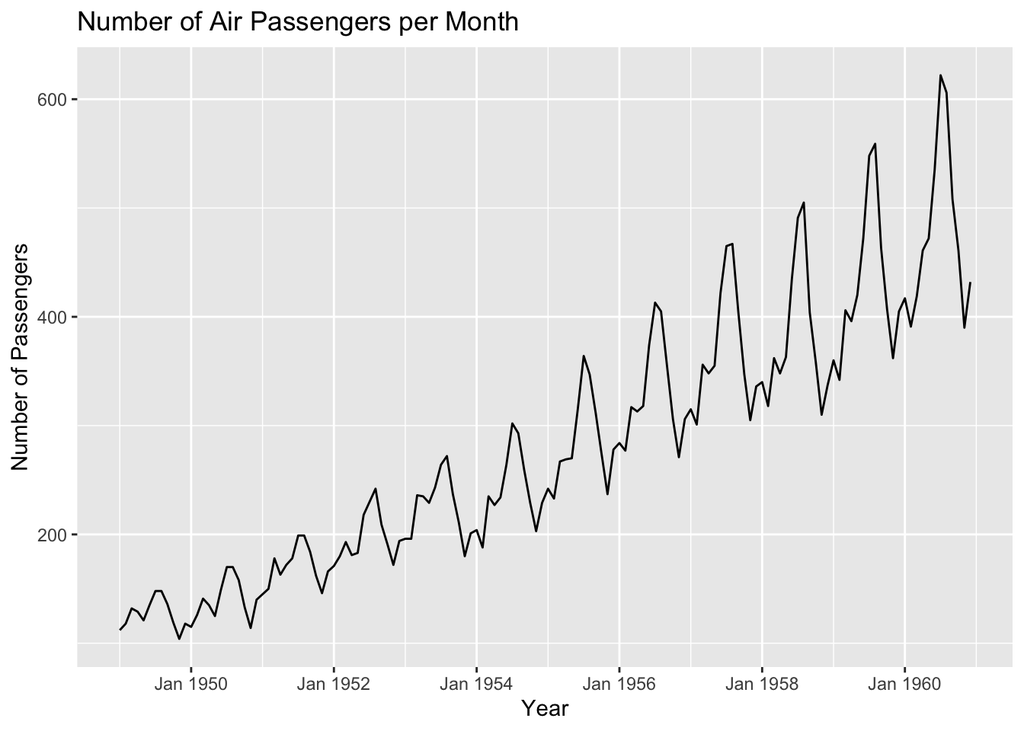

```r
# Plot the time series and label both axes
ggplot(air_passengers.df, aes(x = ds, y = y)) +
  geom_line() +
  labs(title = "Number of Air Passengers per Month", x = "Year", y = "Number of Passengers")
```

### **Results:**

- The graph shows an **upward trend** for the number of passengers over time.
- From this graph we can see that there are regular peaks and dips each year, which are called **seasonal fluctuations**. The peaks show that more people travel in the summer and the dips show that less people travel in the winter.

# **Section 3: Linear Regression Analysis**

## 3.1 Linear Regression Model

We will now use a **linear regression model** to estimate how much the number of air passengers increases each year on average.

```r
# Fit linear regression model
linear_regression_model <- lm(y ~ ds, data = air_passengers.df)
summary(linear_regression_model)
```

```
##
## Call:
## lm(formula = y ~ ds, data = air_passengers.df)
##
## Residuals:
##     Min      1Q  Median      3Q     Max
## -93.858 -30.727  -5.757  24.489 164.999
##
## Coefficients:
##               Estimate Std. Error t value Pr(>|t|)
## (Intercept) -62055.907   2166.077  -28.65   <2e-16 ***
## ds              31.886      1.108   28.78   <2e-16 ***
## ---
## Signif. codes:  0 '***' 0.001 '**' 0.01 '*' 0.05 '.' 0.1 ' ' 1
##
## Residual standard error: 46.06 on 142 degrees of freedom
## Multiple R-squared:  0.8536, Adjusted R-squared:  0.8526
## F-statistic: 828.2 on 1 and 142 DF,  p-value: < 2.2e-16
```

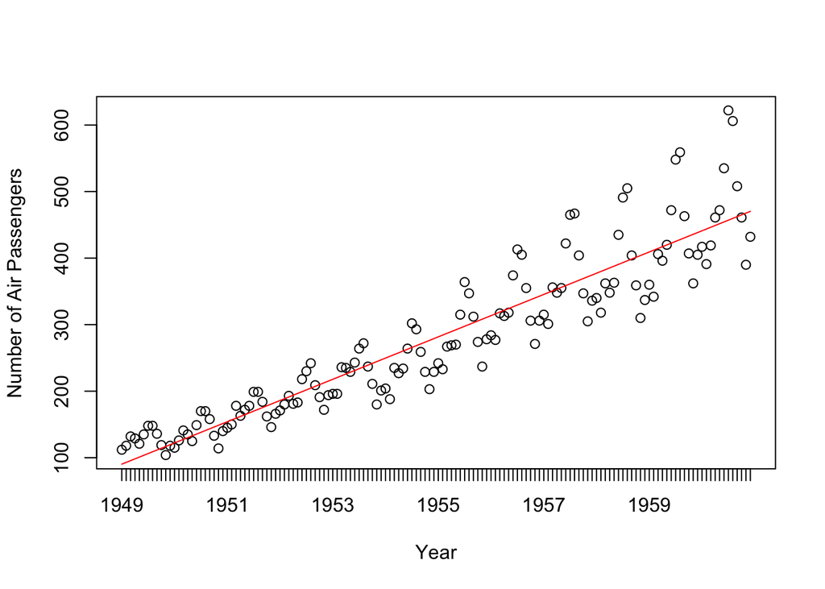

```r
# Plot the linear regression model
plot(air_passengers.df$ds, air_passengers.df$y, type="p", xlab="Year", ylab="Number of Air Passengers")
lines(air_passengers.df$ds, fitted(linear_regression_model), col="red")
```

### **Results:**

- This linear regression model shows an increase in the number of passengers over the years.
- The regression line shows an upward trend, which is what we expect.
- The plots are slowly moving further away from the line. This might show that the data has some seasonal fluctuations which are increasing more and more each year.

# **Section 4: Decomposing the time series**

## 4.1 Decomposition plot

We will now plot the **decomposition of multiplicative time series** to understand the patterns in the data.

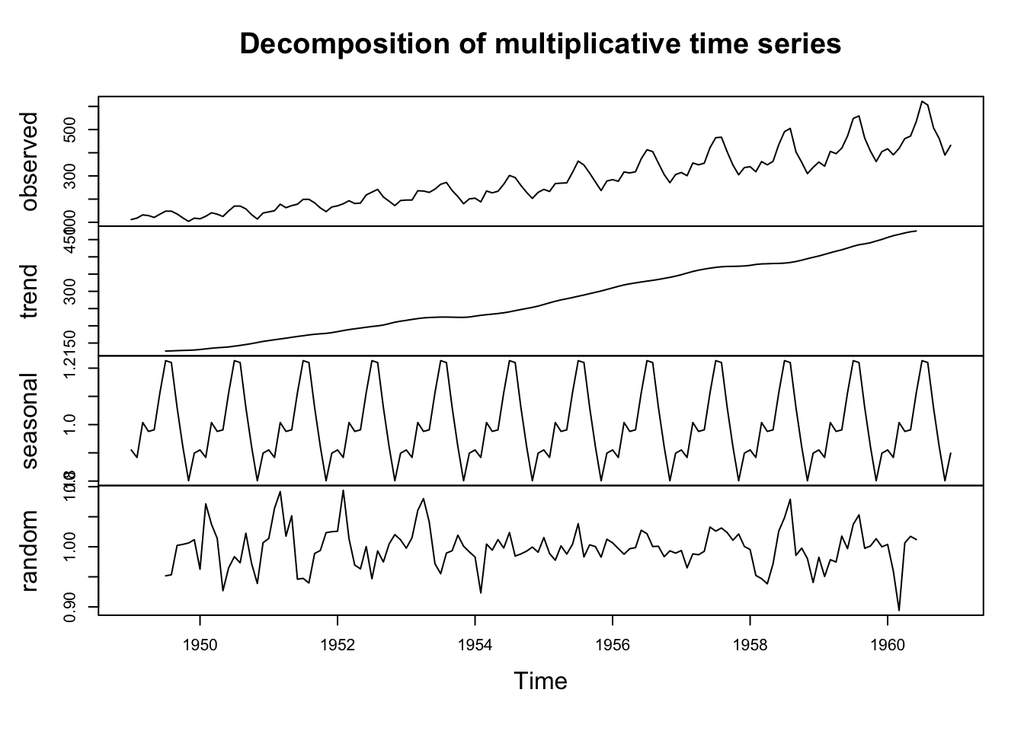

```r
air_passengers_time_series <- ts(air_passengers.df$y, start = c(1949, 1), frequency = 12)

# We will be generating a multiplicative decomposition
decomposed <- decompose(air_passengers_time_series, type = "multiplicative")

# Here we plot the decomposition of the time series
plot(decomposed)
```

### **Results:**

- The **observed data** shows an upward trend and regular peaks. This is a similar pattern to our first plot.
- The **trend data** has removed the fluctuations, and it shows a smooth increase in the number of air passengers over time.
- The **seasonal data** shows the regular peaks. The seasonality doesn’t change over the years, the peaks and dips stay the same.
- The **random noise** data shows no pattern, so this means that the model did a good job of showing the trend.